# ANOVA type I and its friends

# ANOVA Type I Test

Let’s start by generating some sample data and performing an ANOVA Type I test using aov.

```r
# Generate sample data
set.seed(123)
group <- factor(rep(1:3, each = 20))
response <- c(rnorm(20, mean = 50, sd = 5),
              rnorm(20, mean = 55, sd = 5),
              rnorm(20, mean = 60, sd = 5))

data <- data.frame(group, response)

# Perform ANOVA Type I test using aov
anova_model <- aov(response ~ group, data = data)

cat("ANOVA Type I Test Results using aov:\n")
```

```
## ANOVA Type I Test Results using aov:
```

```r
summary(anova_model)
```

```
##             Df Sum Sq Mean Sq F value   Pr(>F)
## group        2  975.4   487.7   22.94 4.91e-08 ***
## Residuals   57 1211.9    21.3
## ---
## Signif. codes:  0 '***' 0.001 '**' 0.01 '*' 0.05 '.' 0.1 ' ' 1
```

We can also perform the ANOVA Type I test using the anova function.

```r
# Perform ANOVA Type I test using anova
anova_model_lm <- lm(response ~ group, data = data)
anova_results <- anova(anova_model_lm)

cat("ANOVA Type I Test Results using anova:\n")
```

```
## ANOVA Type I Test Results using anova:
```

```r
print(anova_results)
```

```
## Analysis of Variance Table
##
## Response: response
##           Df  Sum Sq Mean Sq F value    Pr(>F)
## group      2  975.41  487.71  22.939 4.913e-08 ***
## Residuals 57 1211.90   21.26
## ---
## Signif. codes:  0 '***' 0.001 '**' 0.01 '*' 0.05 '.' 0.1 ' ' 1
```

# Explanation of the Formula Interface in R

In R, the formula interface is used to specify the model to be fitted. The general form of a formula is response ~ predictors. Here, response is the dependent variable, and predictors are the independent variables. The ~ symbol separates the response from the predictors.

For example, in the formula response ~ group, response is the dependent variable, and group is the independent variable. This formula specifies that we want to model the response variable as a function of the group variable.

# Exercises

## Exercise 1: Performing ANOVA on New Data

Generate a new dataset with 4 groups, where each group has 15 samples. Perform an ANOVA Type I test on this new dataset. Display the results.

**Show Solution**

```r
# Generate new sample data
set.seed(456)
group_new <- factor(rep(1:4, each = 15))
response_new <- c(rnorm(15, mean = 50, sd = 5),
                  rnorm(15, mean = 55, sd = 5),
                  rnorm(15, mean = 60, sd = 5),
                  rnorm(15, mean = 65, sd = 5))

data_new <- data.frame(group_new, response_new)

# Perform ANOVA Type I test using aov
anova_model_new <- aov(response_new ~ group_new, data = data_new)

cat("ANOVA Type I Test Results using aov on new data:\n")
```

```
## ANOVA Type I Test Results using aov on new data:
```

```r
summary(anova_model_new)
```

```
##             Df Sum Sq Mean Sq F value   Pr(>F)
## group_new    3   1983   660.9   25.38 1.69e-10 ***
## Residuals   56   1458    26.0
## ---
## Signif. codes:  0 '***' 0.001 '**' 0.01 '*' 0.05 '.' 0.1 ' ' 1
```

## Exercise 2: Visualizing the Data

Create a boxplot to visualize the distribution of responses across the different groups in the new dataset generated in Exercise 1.

**Show Solution**

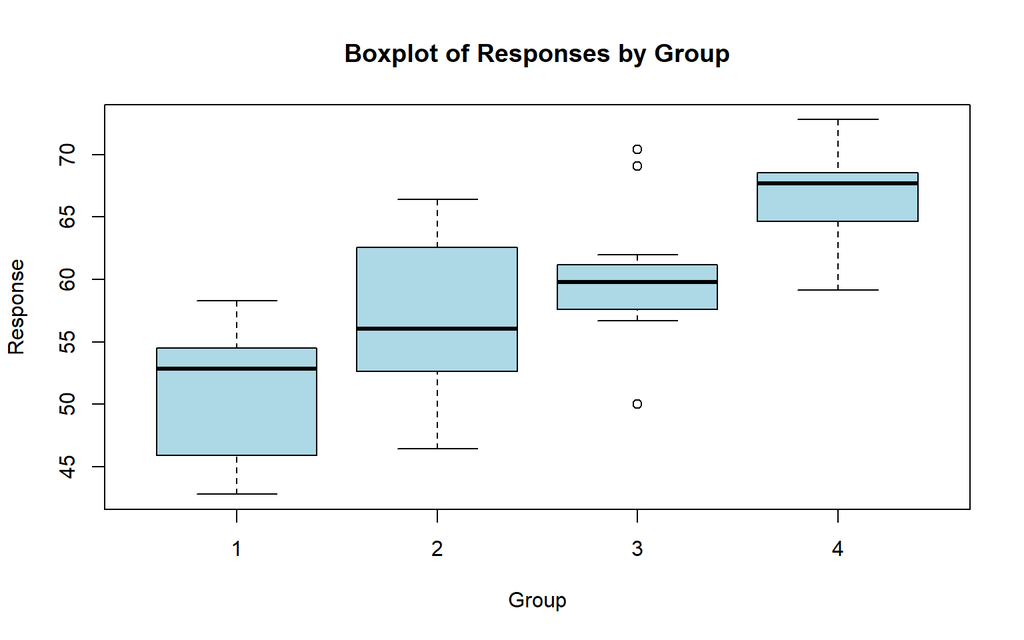

```r
# Boxplot of the new data
boxplot(response_new ~ group_new, data = data_new,
        main = "Boxplot of Responses by Group",
        xlab = "Group", ylab = "Response",
        col = "lightblue")
```

## Exercise 3: ANOVA Assumptions

Discuss the assumptions of ANOVA. Generate diagnostic plots (residuals vs fitted, Q-Q plot) to check these assumptions for the original dataset.

**Show Solution**

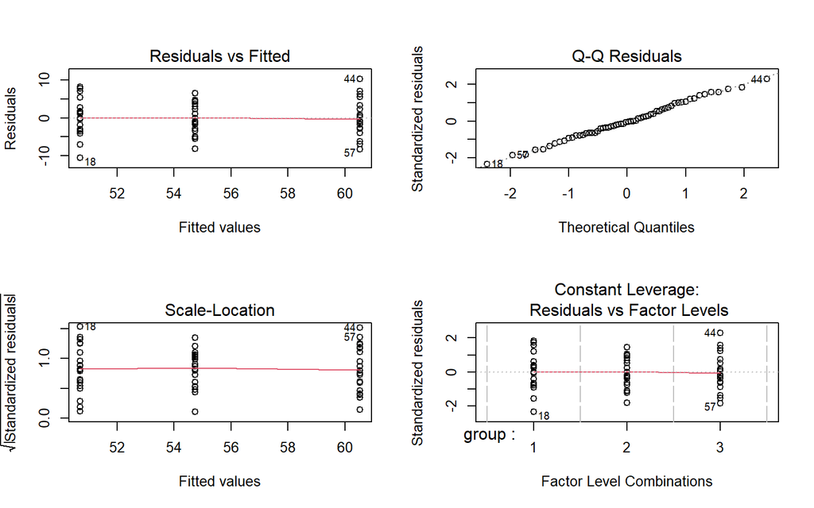

```r
# Diagnostic plots for the original data
par(mfrow = c(2, 2))
plot(anova_model)
```

# Kruskal-Wallis Test

The Kruskal-Wallis test is a non-parametric alternative to ANOVA. It does not assume that the data are normally distributed.

```r
# Perform Kruskal-Wallis test
kruskal_test <- kruskal.test(response ~ group, data = data)

cat("Kruskal-Wallis Test Results:\n")
```

```
## Kruskal-Wallis Test Results:
```

```r
print(kruskal_test)
```

```
##
##  Kruskal-Wallis rank sum test
##
## data:  response by group
## Kruskal-Wallis chi-squared = 27.447, df = 2, p-value = 1.097e-06
```

# Conclusion

In this document, we have demonstrated how to perform an ANOVA Type I test using both aov and anova functions in R. We also explained the formula interface in R and performed a Kruskal-Wallis test as a non-parametric alternative to ANOVA. These techniques are useful for comparing means across multiple groups and understanding the relationships between variables.